# Ensemble Techniques Project

#### Inference:

Out of total 195, 147 is our target class. Though it may prove good for us in terms of accuracy and precision of our target class but it may have bias towards non target class. We may need to balance classes.

##### Checking for outliers:

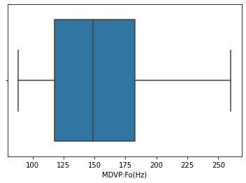

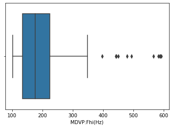

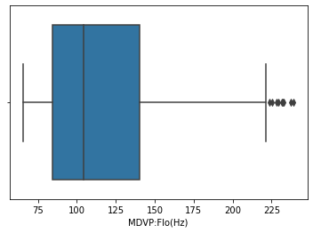

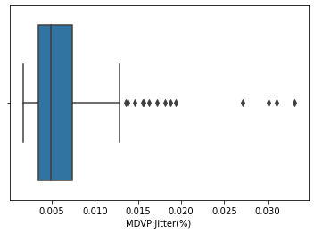

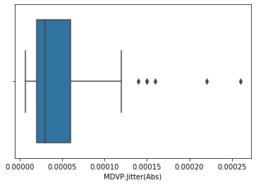

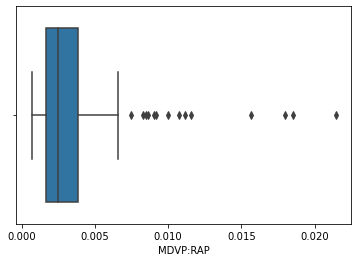

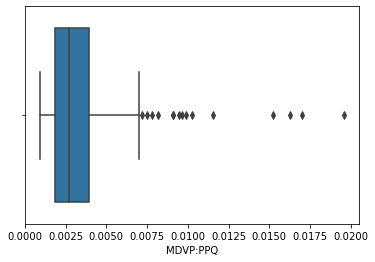

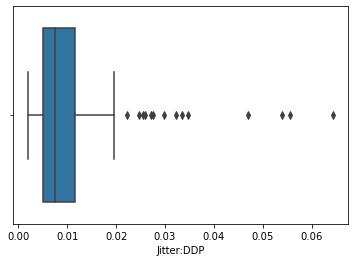

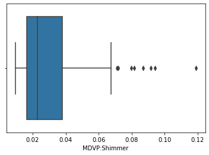

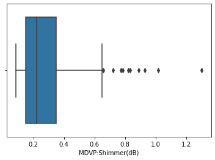

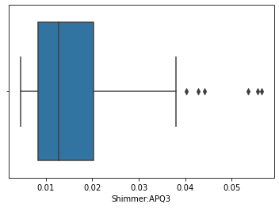

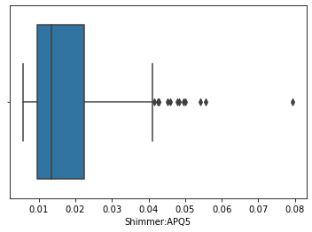

[10 more figures not shown]

```python
for feature in parkDF.columns:
    if(feature not in ['name','status']):
        sns.boxplot(x=feature,hue='status',data=parkDF)
        plt.show()
```

#### Observations:

Many of them have outliers. We might need to work on this before we do modelling.

##### Comment:

There is one more issue here. I don't know whether the outliers are valid or not. If outliers are invalid then we can drop it. But here I don't know their validness as I am not this domain expert, so here considering all of them as valid.

### *BIVARIATE ANALYSIS*

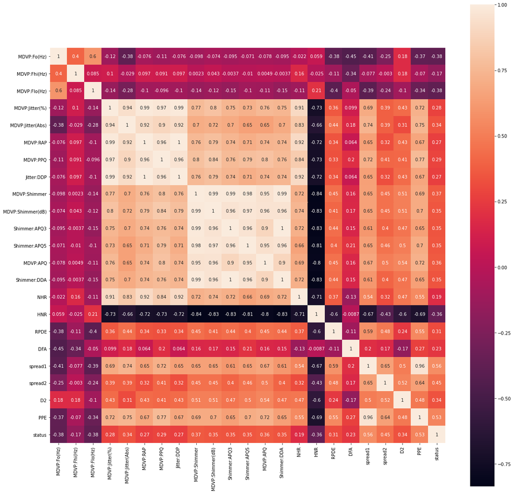

```python
corr = parkDF.corr()
plt.figure(figsize=(20,20))
sns.heatmap(corr,annot=True, square=True)
```

#### Observations:

We see pockets of strong corelations.Two stand out very clearly; "jitter:DDP" and "MDVP:RAP", "Shimmer-APQ3" and "Shimmer-DDA". We could remove these columns for certain models like K-NN. But since I am not an expert at how these parameters impact Parkinsons, we will have to consult and expert to get an opinion if one of these parameters can be dropped Also MDVP:Shimmer has a strong corellation with MDVP:Shimmer(dB), Shimmer:APQ3, Shimmer:APQ5, and Shimmer:DDA

##### We will drop the following Columns for final Modeling as they have linear relationships with other paremeters in their own family:

- name
- Shimmer:DDA
- Jitter:DDP
- MDVP:RAP

##### Analysis of Bar Plots:

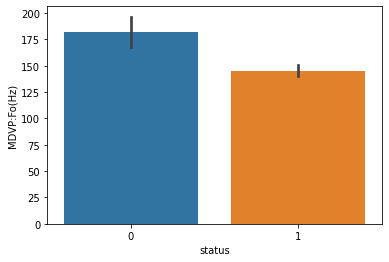

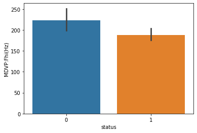

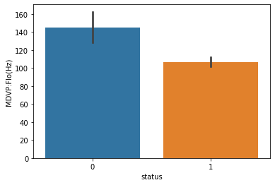

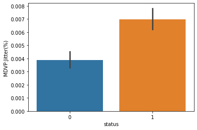

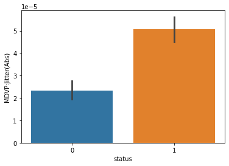

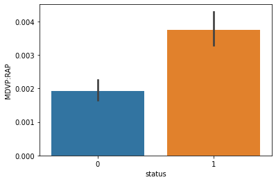

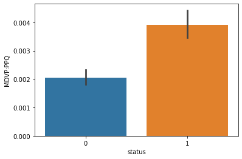

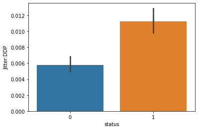

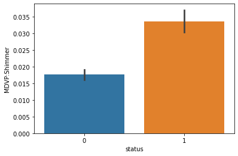

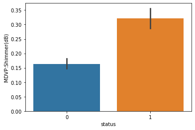

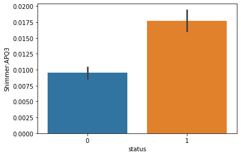

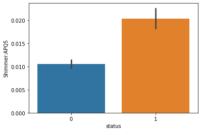

[10 more figures not shown]

```python
for feature in parkDF.columns:
    if (feature not in ['name','status']):
        sns.barplot(x='status',y=feature,data=parkDF)
        plt.show()
```

#### Observations:

Here it is observed that features PPE, spread2, NHR, PPE, spread2, spread1, MDVP:Fo(Hz), Shimmer:APQ3, MDVP:Shimmer(dB), MDVP:Shimmer, Jitter:DDP, MDVP:RAP, MDVP:PPQ, MDVP:Jitter(%), MDVP:Jitter(Abs) looks encouraging becuase of the visible significant difference between the two classes.

##### Ananlysis of Pairplot:

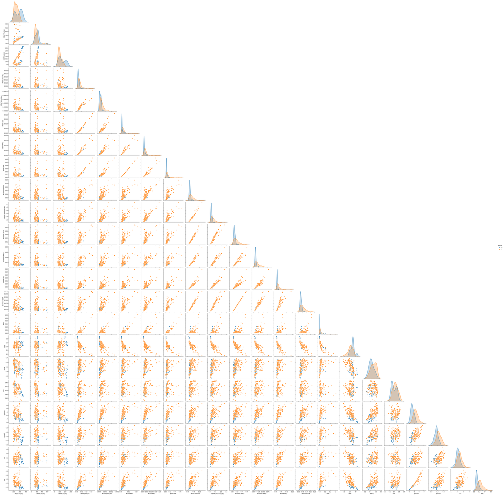

```python
sns.pairplot(data=parkDF,hue='status',corner=True)
plt.show()
```

#### Observations:

Looking at diagonals: MDVP:Fo(Hz), MDVP:Flo(Hz), spread1,spread2,PPE looks to have some separation. These are the features which looks to be good indicators of our target class.

##### Some independent features have linear relation with other independent features:

- MDVP:Jitter(%), MDVP:Jitter(Abs),MDVP:RAP,MDVP:PPQ,Jitter:DDP have some linear relation among each other. All of these are measures of variation in fundamental frequency so it would be a better approach to keep one of them and drop the remaining features.
- Similarly, MDVP:Shimmer, MDVP:Shimmer(dB), Shimmer:APQ3, Shimmer:APQ5, MDVP:APQ, Shimmer:DDA also have linear relation among each other. All of these are measures of variation in fundamental amplitude so it would be a better approach to keep one of them and drop the remaining features.
- Spread1 has linear relation with PPE

###### Notes:

- Now, we need to analyse how much good indicator features together influence status.
- To do that, as all of those features are continuous, we have to make some of them categorical and put that categorical feature on x-axis of swarmplot.
- Process of converting continuous features to categorical is called as discretization or binning.
- We are going to use pandas' cut function to do that.
- Creating binning function.

##### How to Create Bins:

```python
def binning(column, cut_points, labels=None):
    minval = column.min()
    maxval = column.max()
    break_points = [minval] + cut_points + [maxval]
    if not labels:
        labels = range(len(cut_points)+1)
    binned_column = pd.cut(column, bins=break_points, labels=labels, include_lowest=True)
    return binned_column
```

##### Creating a copy of original dataset:

```python
binned_dataset = parkDF.copy()
```

##### Finding Min & Max values of MDVP:Fo(Hz)

```python
feature = 'MDVP:Fo(Hz)'
print(parkDF[feature].min())
print(parkDF[feature].max())
```

```
88.333
260.105
```

##### Finding intervals for MDVP:Fo(Hz) as per min & max values

```python
np.linspace(100,250,4)
```

```
array([100., 150., 200., 250.])
```

##### Binning MDVP:Fo(Hz)

```python
cut_points = [100,150,200,250]
labels = ["Low","Medium","High","Very High","Extremely High"]

binned_dataset["MDVP:Fo(Hz)"] = binning(parkDF["MDVP:Fo(Hz)"], cut_points, labels)
```

##### Finding Min & Max values of MDVP:Flo(Hz)

```python
feature = 'MDVP:Flo(Hz)'
print(parkDF[feature].min())
print(parkDF[feature].max())
```

```
65.476
239.17
```

##### Finding intervals for MDVP:Flo(Hz) as per min & max values

```python
np.linspace(70,220,4)
```

[output not shown]

##### Binning MDVP:Flo(Hz)

```python
cut_points = [70,120,170,220]
labels = ["Low","Medium","High","Very High","Extremely High"]

binned_dataset["MDVP:Flo(Hz)"] = binning(parkDF["MDVP:Flo(Hz)"], cut_points, labels)
```

##### Finding Min & Max values of PPE

```python
feature = 'PPE'
print(parkDF[feature].min())
print(parkDF[feature].max())
```

```
0.044538999999999995
0.527367
```

##### Finding intervals for PPE as per min & max values

```python
np.linspace(0.05,0.50,4)
```

```
array([0.05, 0.2 , 0.35, 0.5 ])
```

##### Binning PPE

```python
cut_points = [0.05, 0.2 , 0.35, 0.5 ]
labels = ["Low","Medium","High","Very High","Extremely High"]

binned_dataset["PPE"] = binning(parkDF["PPE"], cut_points, labels)
```

##### 01 Checking influence of MDVP:Fo(Hz) & MDVP:Flo(Hz) on status

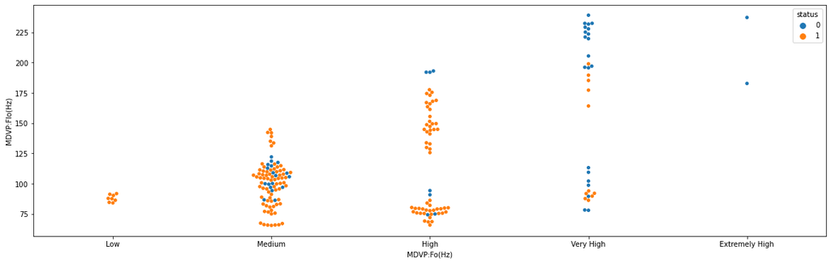

```python
plt.figure(figsize=(20,6))
sns.swarmplot(x=binned_dataset['MDVP:Fo(Hz)'],y=parkDF['MDVP:Flo(Hz)'],hue=parkDF['status'] )
plt.show()
```

#### Inferences:

- Combination of low MDVP:Fo(Hz) upto 100Hz & MDVP:Flo(Hz) less than 100Hz are high relation with PD. We can see all orange dots for MDVP:Fo(Hz) = Low & MDVP:Flo(Hz) less than 100
- medium MDVP:Fo(Hz) (between 101 & 150) along with MDVP:Flo(Hz) upto 150Hz also have high relation with PD.
- high MDVP:Fo(Hz) (between 151 & 200) along with MDVP:Flo(Hz) upto 175Hz also have high relation with PD.
- There are some instances of PD in range of very high MDVP:Fo(Hz) also.

##### 02 Checking influence of MDVP:Fo(Hz) & PPE on status.

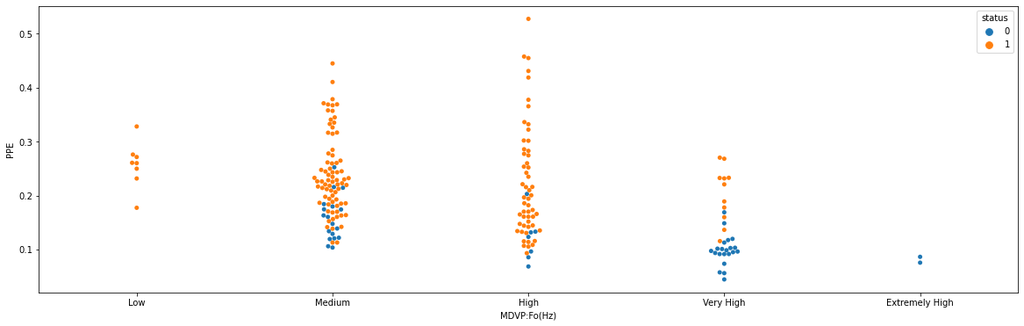

```python
plt.figure(figsize=(20,6))
sns.swarmplot(x=binned_dataset['MDVP:Fo(Hz)'],y=parkDF['PPE'],hue=parkDF['status'] )
plt.show()
```

#### Inferences:

- 8 instances of low MDVP:Fo(Hz) upto 100Hz with PPE (from 0.19 to 0.31) are related with PD.
- Several instances of PD are visible for medium & high MDVP:Fo(Hz) with PPE(from 0.1 to 0.45).
- Few instances of PD are visible for very high MDVP:Fo(Hz) also along with PPE(from around 0.12 to 0.25).

##### 03 Checking influence of PPE & MDVP:Flo(Hz) on status.

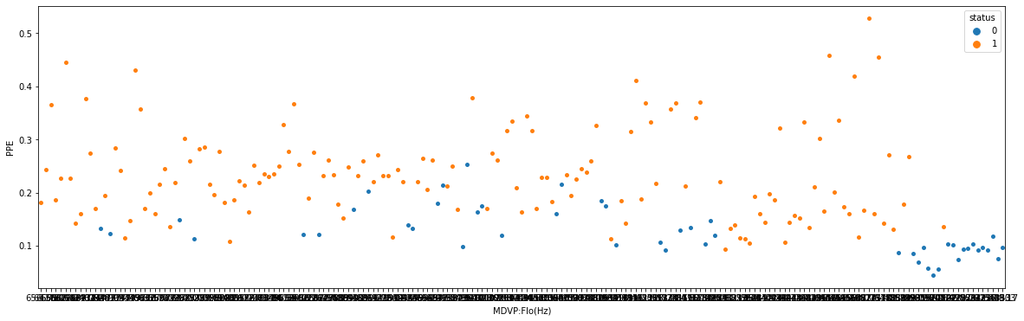

```python
plt.figure(figsize=(20,6))
sns.swarmplot(x=binned_dataset['MDVP:Flo(Hz)'],y=parkDF['PPE'],hue=parkDF['status'] )
plt.show()
```

#### Inferences:

##### 04 Checking influence of MDVP:Fo(Hz) & spread1 on status.

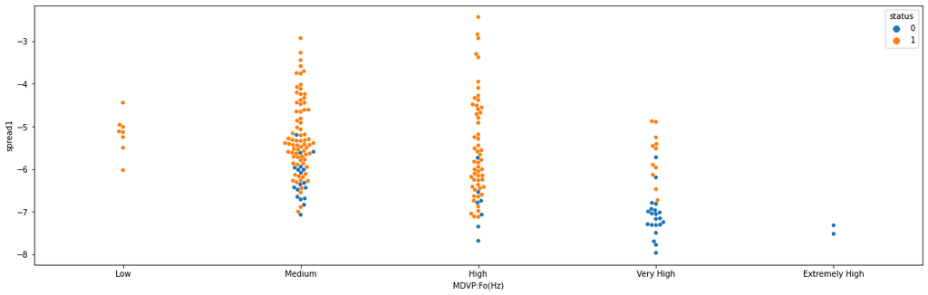

```python
plt.figure(figsize=(20,6))
sns.swarmplot(x=binned_dataset['MDVP:Fo(Hz)'],y=parkDF['spread1'],hue=parkDF['status'] )
plt.show()
```

#### Inferences:

- 8 instances of low MDVP:Fo(Hz) upto 100Hz with spread1 (from around -6 to -4.5) are related with PD.
- Several instances of PD are visible for medium with spread1(from around -7 to -3).
- Several instances of PD are visible for high MDVP:Fo(Hz) with spread1(from around -7 to more than -3).
- Few instances of PD are visible for very high MDVP:Fo(Hz) also along with PPE(from around -6.5 to -5).

##### 05 Checking influence of MDVP:Flo(Hz) & spread1 on status.

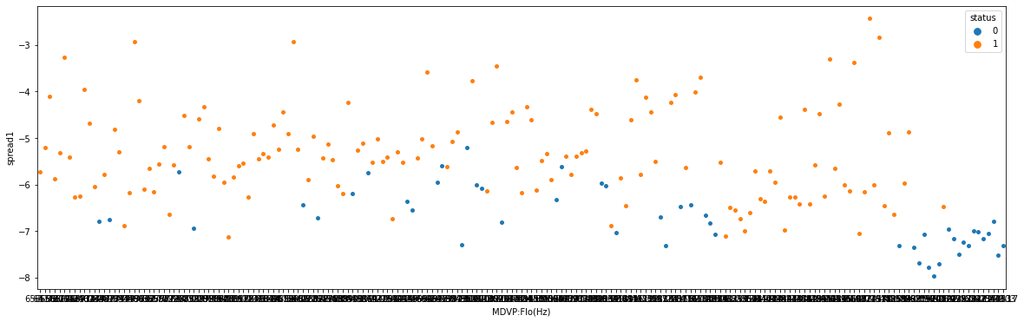

```python
plt.figure(figsize=(20,6))
sns.swarmplot(x=binned_dataset['MDVP:Flo(Hz)'],y=parkDF['spread1'],hue=parkDF['status'] )
plt.show()
```

#### Inferences:

##### 06 Checking influence of PPE & spread1 on status.

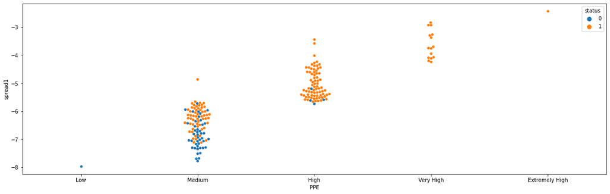

```python
plt.figure(figsize=(20,6))
sns.swarmplot(x=binned_dataset['PPE'],y=parkDF['spread1'],hue=parkDF['status'] )
plt.show()
```

#### 07 Checking influence of MDVP:Fo(Hz) & spread2 on status.

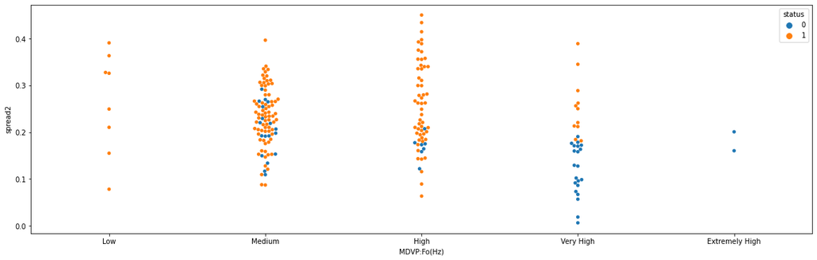

```python
plt.figure(figsize=(20,6))
sns.swarmplot(x=binned_dataset['MDVP:Fo(Hz)'],y=parkDF['spread2'],hue=parkDF['status'] )
plt.show()
```

#### Inferences:

- Same 8 instances of low MDVP:Fo(Hz) upto 100Hz with spread2 are related with PD but with spread2, they are more spread over the range from around 0.09 to 0.4. With spread1, instances were densed in a shorter range.
- Several instances of PD are visible for medium with spread2(from around 0.1 to 0.35).
- Several instances of PD are visible for high MDVP:Fo(Hz) with spread2 just like spread1.
- Few instances of PD are visible for very high MDVP:Fo(Hz) also along with spread2 on higher range of spread2.

#### 08 Checking influence of MDVP:Flo(Hz) & spread2 on status.

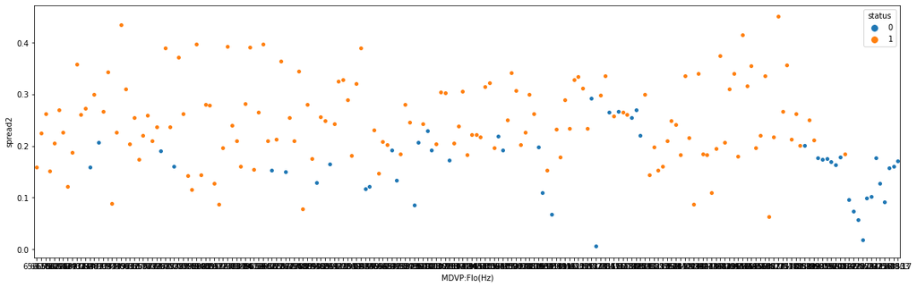

```python
plt.figure(figsize=(20,6))
sns.swarmplot(x=binned_dataset['MDVP:Flo(Hz)'],y=parkDF['spread2'],hue=parkDF['status'] )
plt.show()
```

#### 09 Checking influence of PPE & spread2 on status.

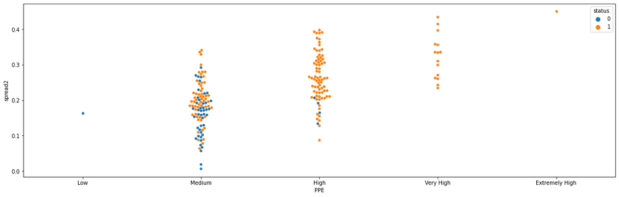

```python
plt.figure(figsize=(20,6))
sns.swarmplot(x=binned_dataset['PPE'],y=parkDF['spread2'],hue=parkDF['status'] )
plt.show()
```

#### Inferences:

- Relation of PPE with spread2 is quite similar with what it has with spread1.
- As value of PPE increasing, cases of PD are increasing and points are getting densed.

### 4. Split the dataset into training and test set in the ratio of 70:30 (Training:Test) (5 points)

Before splitting the Training and Testing we will:

- Drop some columns that have a linear relationship with other columns
- Split the data set into X and y

```python
parkDF.head()
X = parkDF.drop('status', axis=1) # X axis without the Target Variable
y= parkDF['status'] # target variable on y Axis
cols = X.columns
print(cols)
X_train, X_test, y_train, y_test = train_test_split(X, y, test_size=0.3, random_state=10)
```

```
Index(['MDVP:Fo(Hz)', 'MDVP:Fhi(Hz)', 'MDVP:Flo(Hz)', 'MDVP:Jitter(%)',
       'MDVP:Jitter(Abs)', 'MDVP:PPQ', 'MDVP:Shimmer', 'MDVP:Shimmer(dB)',
       'Shimmer:APQ3', 'Shimmer:APQ5', 'MDVP:APQ', 'NHR', 'HNR', 'RPDE', 'DFA',
       'spread1', 'spread2', 'D2', 'PPE'],
      dtype='object')
```

```python
X_train.head()
```

|  | MDVP:Fo(Hz) | MDVP:Fhi(Hz) | MDVP:Flo(Hz) | MDVP:Jitter(%) | MDVP:Jitter(Abs) | MDVP:PPQ | MDVP:Shimmer | MDVP:Shimmer(dB) | Shimmer:APQ3 | Shimmer:APQ5 | MDVP:APQ | NHR | HNR | RPDE | DFA | spread1 | spread2 | D2 | PPE |
| --- | --- | --- | --- | --- | --- | --- | --- | --- | --- | --- | --- | --- | --- | --- | --- | --- | --- | --- | --- |
| 49 | 122.964 | 130.049 | 114.676 | 0.00428 | 0.00003 | 0.00155 | 0.01681 | 0.154 | 0.00930 | 0.00802 | 0.01400 | 0.00462 | 24.971 | 0.538688 | 0.754073 | -6.482096 | 0.264967 | 2.054419 | 0.128872 |
| 180 | 150.440 | 163.441 | 144.736 | 0.00396 | 0.00003 | 0.00233 | 0.02551 | 0.237 | 0.01321 | 0.01574 | 0.02148 | 0.00611 | 23.133 | 0.352396 | 0.759320 | -6.261446 | 0.183218 | 2.264226 | 0.144105 |
| 102 | 139.224 | 586.567 | 66.157 | 0.03011 | 0.00022 | 0.01628 | 0.09419 | 0.930 | 0.05551 | 0.05005 | 0.06023 | 0.25930 | 10.489 | 0.596362 | 0.641418 | -3.269487 | 0.270641 | 2.690917 | 0.444774 |
| 151 | 192.818 | 224.429 | 168.793 | 0.03107 | 0.00016 | 0.01958 | 0.11908 | 1.302 | 0.05647 | 0.07940 | 0.13778 | 0.21713 | 8.441 | 0.625866 | 0.768320 | -2.434031 | 0.450493 | 3.079221 | 0.527367 |
| 91 | 151.955 | 163.335 | 147.226 | 0.00419 | 0.00003 | 0.00227 | 0.07959 | 0.772 | 0.04421 | 0.04962 | 0.05690 | 0.01658 | 19.664 | 0.501037 | 0.714360 | -6.411497 | 0.207156 | 2.344876 | 0.134120 |

### 5. Prepare the data for training -Scale the data if necessary, get rid of missing values (if any) etc (5 points)

Since there is a lot of variation in the various Column values, some are large numbers and some are fractions, lets scale all the columns by using a MinMax Scaler

```python
# Let us scale training data set test data using MinMaxScaler
scaler = MinMaxScaler()
train_scaled = scaler.fit_transform(X_train)
test_scaled = scaler.fit_transform(X_test)

X_train_scaled = pd.DataFrame(train_scaled)
X_test_scaled = pd.DataFrame(test_scaled)

# Replace the Columns Headers back
X_train_scaled.columns = cols
X_test_scaled.columns = cols
X_train_scaled.head()
```

|  | MDVP:Fo(Hz) | MDVP:Fhi(Hz) | MDVP:Flo(Hz) | MDVP:Jitter(%) | MDVP:Jitter(Abs) | MDVP:PPQ | MDVP:Shimmer | MDVP:Shimmer(dB) | Shimmer:APQ3 | Shimmer:APQ5 | MDVP:APQ | NHR | HNR | RPDE | DFA | spread1 | spread2 | D2 | PPE |
| --- | --- | --- | --- | --- | --- | --- | --- | --- | --- | --- | --- | --- | --- | --- | --- | --- | --- | --- | --- |
| 0 | 0.204969 | 0.046115 | 0.293524 | 0.082592 | 0.083665 | 0.033762 | 0.066368 | 0.056697 | 0.091487 | 0.031479 | 0.052148 | 0.012636 | 0.671787 | 0.652517 | 0.721467 | 0.268107 | 0.582355 | 0.280769 | 0.174665 |
| 1 | 0.386287 | 0.115061 | 0.473864 | 0.072427 | 0.083665 | 0.075563 | 0.145791 | 0.124897 | 0.166795 | 0.136228 | 0.109426 | 0.017379 | 0.597090 | 0.210540 | 0.742522 | 0.308001 | 0.398326 | 0.374105 | 0.206214 |
| 2 | 0.312271 | 0.988720 | 0.002442 | 0.903113 | 0.840637 | 0.823151 | 0.772777 | 0.694330 | 0.981510 | 0.601764 | 0.406157 | 0.823280 | 0.083232 | 0.789348 | 0.269404 | 0.848949 | 0.595128 | 0.563925 | 0.828939 |
| 3 | 0.665945 | 0.240988 | 0.618190 | 0.933609 | 0.601594 | 1.000000 | 1.000000 | 1.000000 | 1.000000 | 1.000000 | 1.000000 | 0.689054 | 0.000000 | 0.859347 | 0.778637 | 1.000000 | 1.000000 | 0.736669 | 1.000000 |
| 4 | 0.396285 | 0.114843 | 0.488802 | 0.079733 | 0.083665 | 0.072347 | 0.639492 | 0.564503 | 0.763867 | 0.595929 | 0.380657 | 0.050705 | 0.456108 | 0.563190 | 0.562106 | 0.280871 | 0.452214 | 0.409984 | 0.185534 |

```python
numRows = X_train_scaled.count(axis=0)[0]
print("Total no. of rows in the training set: ", numRows)
numRows = X_test_scaled.count(axis=0)[0]
print("Total no. of rows in the testing set: ", numRows)
```

```
Total no. of rows in the training set:  136
Total no. of rows in the testing set:  59
```

### 6. Train at least 3 standard classification algorithms -Logistic Regression, Naive Bayes’, SVM, k-NN etc, and note down their accuracies on the test data (10 points)

*I WILL USE THE FOLLOWING MODELS:*

- k-NN
- SVM
- Naive Bayes
- Logistic REgressions

##### We will then use a Meta Classifier and use these Models in a StackClassifer to get the best results

Before we start building and testing models, let us define some functions to help us reduce Code

```python
# A Dataframe to store Model Performance Results
perf_column_name = ['Model','Train Accu','Test Accu','F1-Score','Recall','AUC']
perfDF = pd.DataFrame(columns = perf_column_name)

#Function to collect and add Model Performance Results
def BuildPerformanceData(model, modelname, y_predict, perfDF):
    class_rep = classification_report(y_test,y_predict, output_dict=True)
        #AUC Calculations
    fpr, tpr, thresholds = metrics.roc_curve(y_test, y_predict, pos_label=1)
    arg1 = round(model.score(X_train_scaled,y_train) * 100,2)
    arg2 = round(model.score(X_test_scaled,y_test) * 100,2)
    arg4 = round(class_rep['1']['f1-score'] * 100, 2)
    arg5 = round(class_rep['1']['recall'] * 100,2)
    arg6 = round(metrics.auc(fpr, tpr)*100,2)
    perfDF = perfDF.append({'Model':modelname,'Train Accu':arg1,'Test Accu':arg2, 'F1-Score':arg4,'Recall':arg5,'AUC':arg6},ignore_index=True)
    return perfDF

#Function to print Confusion Matrix and Classification Report
def Print_CM_CR_AUC(y_test,y_predict, algoname):
    cm = confusion_matrix(y_test,y_predict)
    sns.heatmap(cm,annot=True, fmt='.2f', xticklabels=[0,1], yticklabels=[0,1])
    plt.ylabel('observed')
    plt.xlabel('Predicted')
    plt.show()
    # get accuracy of model
    acc_score = accuracy_score(y_test,y_predict)
    # get F1-score of model
    F1_score = f1_score(y_test,y_predict)
    # get the classification report
    class_rep = classification_report(y_test,y_predict)

    print("Accuracy of ", algoname, " is {} %".format(acc_score*100))
    print("F1-score of ", algoname, " is {} %".format(F1_score*100))
    print("Classification report for ", algoname, " is: \n",class_rep)

    #AUC Calculations
    fpr, tpr, thresholds = metrics.roc_curve(y_test, y_predict, pos_label=1)
    print("AUC for ", algoname, ":", round(metrics.auc(fpr, tpr)*100,2))
```

### 6.1 kNN

Lets do an Elbow analysis to find the best depth

```python
error_rate = []

for i in range(1,100):
 NNH = KNeighborsClassifier(n_neighbors=i)
 NNH.fit(X_train_scaled,y_train)
 KNN_predicted_labels = NNH.predict(X_test_scaled)
 error_rate.append(np.mean(KNN_predicted_labels != y_test))
```

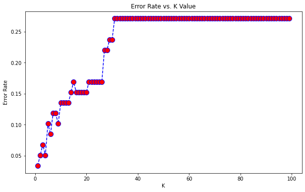

```python
plt.figure(figsize=(10,6))
plt.plot(range(1,100),error_rate,color= 'blue', linestyle='dashed', marker='o', markerfacecolor='red', markersize=10)
plt.title('Error Rate vs. K Value')
plt.xlabel('K')
plt.ylabel('Error Rate')
```

#### Observation:

**K = 4** should be a good number for KNN as that's the first sharp Elbow

Since we have a few models to test, lets write a function to add Performance Data to a Dataframe that we can use later to evaluate

```python
# From the
K = 4

NNH = KNeighborsClassifier(n_neighbors= K)

# Call Nearest Neighbour algorithm
NNH.fit(X_train_scaled, y_train)
```

```
KNeighborsClassifier(n_neighbors=4)
```

```python
#Predict using the test data and score the result

KNN_predicted_labels = NNH.predict(X_train_scaled)
train_acc = metrics.accuracy_score(y_train, KNN_predicted_labels)
print("Model Accuracy with Training Data: {0:.4f}".format(metrics.accuracy_score(y_train, KNN_predicted_labels)*100))
print()

KNN_predicted_labels = NNH.predict(X_test_scaled)
test_acc = metrics.accuracy_score(y_test, KNN_predicted_labels)
print("Model Accuracy with Testing Data: {0:.4f}".format(metrics.accuracy_score(y_test, KNN_predicted_labels)*100))
print()
```

```
Model Accuracy with Training Data: 94.8529

Model Accuracy with Testing Data: 94.9153
```

#### Observation:

KNN Algorithm seems to havea good Accuracy for Training and Testing Dataset

### 6.2 SVM Model

SVM uses Gamma and C as two hyper parameters. To choose the best values for gamma and C, GridSearchCV should be used. However, the code was giving zero_division errors and I could not trust the result. For for now we will use a C=100 and gamma = 0.001

```python
# Set the parameters by cross-validation
#tuned_parameters = [{'kernel': ['rbf'], 'gamma': [1e-3, 1e-4],
#                     'C': [1, 10, 100, 1000]},
#                    {'kernel': ['linear'], 'C': [1, 10, 100, 1000]}]

#scores = ['precision', 'recall']

#for score in scores:
#    try:
#        print("# Tuning hyper-parameters for %s" % score)
#        print()
#
#        clf = GridSearchCV(
#            SVC(), tuned_parameters, scoring='%s_macro' % score
#        )
#        clf.fit(X_train_scaled, y_train)

#        print("Best parameters set found on development set:")
#        print()
#        print(clf.best_params_)
#        print()
#        print("Grid scores on development set:")
#        print()
#        means = clf.cv_results_['mean_test_score']
#        stds = clf.cv_results_['std_test_score']
#        for mean, std, params in zip(means, stds, clf.cv_results_['params']):
#            print("%0.3f (+/-%0.03f) for %r"
#                  % (mean, std * 2, params))
#        print()
#
#        print("Detailed classification report:")
#        print()
#        print("The model is trained on the full development set.")
#        print("The scores are computed on the full evaluation set.")
#        print()
#        y_true, y_pred = y_test, clf.predict(X_test)
#        print(classification_report(y_true, y_pred))
#        print()
#    except ZeroDivisionError:
#        res.append(0)
```

```python
C = 100
gamma=0.001
SVCL = svm.SVC(C=C,gamma=gamma)
SVCL.fit(X_train_scaled , y_train)
SVC_Predicted_labels = SVCL.predict(X_train_scaled)

print("Model Accuracy with Training Data: {0:.4f}".format(metrics.accuracy_score(y_train, SVC_Predicted_labels)*100))
print()

SVC_Predicted_labels = SVCL.predict(X_test_scaled)

print("Model Accuracy with Testing Data: {0:.4f}".format(metrics.accuracy_score(y_test, SVC_Predicted_labels)*100))
print()
```

```
Model Accuracy with Training Data: 76.4706

Model Accuracy with Testing Data: 74.5763
```

### 6.3 Naive Bayes Model

```python
# creat the model
GNB = GaussianNB()
GNB.fit(X_train_scaled, y_train)
GNB_predicted_labels = GNB.predict(X_train_scaled)

print("Model Accuracy with Training Data: {0:.4f}".format(metrics.accuracy_score(y_train, GNB_predicted_labels)*100))
print()

GNB_predicted_labels = GNB.predict(X_test_scaled)

print("Model Accuracy with Testing data: {0:.4f}".format(metrics.accuracy_score(y_test, GNB_predicted_labels)*100))
print()
```

```
Model Accuracy with Training Data: 67.6471

Model Accuracy with Testing data: 86.4407
```

### 6.4 Logistic Regression

While not overfitted, the difference between Training and Accuracy and Testing Accuracy is a bit more. Since accuracy levels are low, lets also test Logistic Regression

```python
# Fit the model on train
LR = LogisticRegression(solver="liblinear")
LR.fit(X_train_scaled, y_train)
LR_predicted_labels = LR.predict(X_train_scaled)

print("Model Accuracy with Training Data: {0:.4f}".format(metrics.accuracy_score(y_train, LR_predicted_labels)*100))
print()

LR_predicted_labels = LR.predict(X_test_scaled)

print("Model Accuracy with Testing data: {0:.4f}".format(metrics.accuracy_score(y_test, LR_predicted_labels)*100))
print()
```

```
Model Accuracy with Training Data: 84.5588

Model Accuracy with Testing data: 86.4407
```

### Observation:

**Now lets do a confusion matrix analysis analisys of these Algorithms and also collect all the Performance Data into a DataFrame so we can analyse all the Models together at the end**

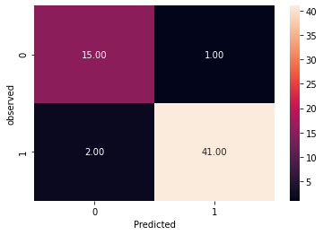

```
Accuracy of  KNN  is 94.91525423728814 %
F1-score of  KNN  is 96.47058823529412 %
Classification report for  KNN  is:
               precision    recall  f1-score   support

           0       0.88      0.94      0.91        16
           1       0.98      0.95      0.96        43

    accuracy                           0.95        59
   macro avg       0.93      0.95      0.94        59
weighted avg       0.95      0.95      0.95        59

AUC for  KNN : 94.55
```

|  | Model | Train Accu | Test Accu | F1-Score | Recall | AUC |
| --- | --- | --- | --- | --- | --- | --- |
| 0 | KNN | 94.85 | 94.92 | 96.47 | 95.35 | 94.55 |

```python
#Draw Confusion Matrix and Classification Report for KNN
Print_CM_CR_AUC(y_test,KNN_predicted_labels, "KNN")
perfDF = BuildPerformanceData(NNH, "KNN", KNN_predicted_labels, perfDF)
perfDF
```

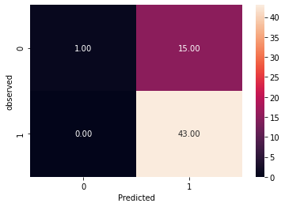

```
Accuracy of  SVC  is 74.57627118644068 %
F1-score of  SVC  is 85.14851485148515 %
Classification report for  SVC  is:
               precision    recall  f1-score   support

           0       1.00      0.06      0.12        16
           1       0.74      1.00      0.85        43

    accuracy                           0.75        59
   macro avg       0.87      0.53      0.48        59
weighted avg       0.81      0.75      0.65        59

AUC for  SVC : 53.12
```

|  | Model | Train Accu | Test Accu | F1-Score | Recall | AUC |
| --- | --- | --- | --- | --- | --- | --- |
| 0 | KNN | 94.85 | 94.92 | 96.47 | 95.35 | 94.55 |
| 1 | SVC | 76.47 | 74.58 | 85.15 | 100.00 | 53.12 |

```python
#Draw Confusion Matrix and Classification Report for SVM
Print_CM_CR_AUC(y_test,SVC_Predicted_labels, "SVC")
perfDF = BuildPerformanceData(SVCL, "SVC", SVC_Predicted_labels, perfDF)
perfDF
```

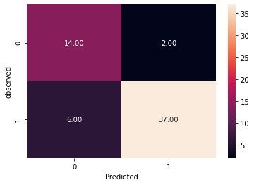

```
Accuracy of  Naive Bayes  is 86.4406779661017 %
F1-score of  Naive Bayes  is 90.2439024390244 %
Classification report for  Naive Bayes  is:
               precision    recall  f1-score   support

           0       0.70      0.88      0.78        16
           1       0.95      0.86      0.90        43

    accuracy                           0.86        59
   macro avg       0.82      0.87      0.84        59
weighted avg       0.88      0.86      0.87        59

AUC for  Naive Bayes : 86.77
```

|  | Model | Train Accu | Test Accu | F1-Score | Recall | AUC |
| --- | --- | --- | --- | --- | --- | --- |
| 0 | KNN | 94.85 | 94.92 | 96.47 | 95.35 | 94.55 |
| 1 | SVC | 76.47 | 74.58 | 85.15 | 100.00 | 53.12 |
| 2 | Naive Bayes | 67.65 | 86.44 | 90.24 | 86.05 | 86.77 |

```python
#Draw Confusion Matrix and Classification Report for Naive Bayes
Print_CM_CR_AUC(y_test,GNB_predicted_labels, "Naive Bayes")
perfDF = BuildPerformanceData(GNB, "Naive Bayes", GNB_predicted_labels, perfDF)
perfDF
```

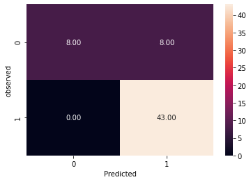

```
Accuracy of  Logistic Regression  is 86.4406779661017 %
F1-score of  Logistic Regression  is 91.48936170212765 %
Classification report for  Logistic Regression  is:
               precision    recall  f1-score   support

           0       1.00      0.50      0.67        16
           1       0.84      1.00      0.91        43

    accuracy                           0.86        59
   macro avg       0.92      0.75      0.79        59
weighted avg       0.89      0.86      0.85        59

AUC for  Logistic Regression : 75.0
```

|  | Model | Train Accu | Test Accu | F1-Score | Recall | AUC |
| --- | --- | --- | --- | --- | --- | --- |
| 0 | KNN | 94.85 | 94.92 | 96.47 | 95.35 | 94.55 |
| 1 | SVC | 76.47 | 74.58 | 85.15 | 100.00 | 53.12 |
| 2 | Naive Bayes | 67.65 | 86.44 | 90.24 | 86.05 | 86.77 |
| 3 | Logistic Regression | 84.56 | 86.44 | 91.49 | 100.00 | 75.00 |

```python
#Draw Confusion Matrix and Classification Report for Logistic Regression
Print_CM_CR_AUC(y_test,LR_predicted_labels, "Logistic Regression")
perfDF = BuildPerformanceData(LR, "Logistic Regression", LR_predicted_labels, perfDF)
perfDF
```

#### Observation:

**Conclusion:** Given this Data, I would go with KNN. KNN is anyway a good choice for Medical Classification problems. But given more Data, I would retrain Logical Regression and see how it performs and then make a choice.

### 7. Train a meta-classifier and note the accuracy on test data (10 points)

Lets train a Meta Classifier to use the above algorithms and use a Logistic Regression as the final model to chose the best model. We will use the same Models and the Same parameters to build a Meta Classifier

```python
estimators = [
    ('knn', KNeighborsClassifier(n_neighbors= K)),
     ('svm', svm.SVC(gamma=gamma, C=C)),
     ('gnb', GaussianNB()),
     ('lr', LogisticRegression(solver="liblinear"))
]

STCL = StackingClassifier(estimators=estimators, final_estimator=LogisticRegression())

STCL.fit(X_train_scaled, y_train)

print("Model Accuracy with Training Data: {0:.4f}".format(STCL.score(X_train_scaled,y_train)*100))
print()

print("Model Accuracy with Testing Data: {0:.4f}".format(STCL.score(X_test_scaled,y_test)*100))
print()

STCL_predicted_labels = STCL.predict(X_test_scaled)
```

```
Model Accuracy with Training Data: 94.8529

Model Accuracy with Testing Data: 94.9153
```

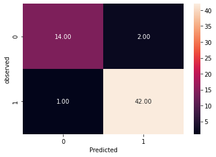

```
Accuracy of  Meta Classifier  is 94.91525423728814 %
F1-score of  Meta Classifier  is 96.55172413793103 %
Classification report for  Meta Classifier  is:
               precision    recall  f1-score   support

           0       0.93      0.88      0.90        16
           1       0.95      0.98      0.97        43

    accuracy                           0.95        59
   macro avg       0.94      0.93      0.93        59
weighted avg       0.95      0.95      0.95        59

AUC for  Meta Classifier : 92.59
```

|  | Model | Train Accu | Test Accu | F1-Score | Recall | AUC |
| --- | --- | --- | --- | --- | --- | --- |
| 0 | KNN | 94.85 | 94.92 | 96.47 | 95.35 | 94.55 |
| 1 | SVC | 76.47 | 74.58 | 85.15 | 100.00 | 53.12 |
| 2 | Naive Bayes | 67.65 | 86.44 | 90.24 | 86.05 | 86.77 |
| 3 | Logistic Regression | 84.56 | 86.44 | 91.49 | 100.00 | 75.00 |
| 4 | Meta Classifier | 94.85 | 94.92 | 96.55 | 97.67 | 92.59 |

```python
#Draw Confusion Matrix and Classification Report for Logistic Regression
Print_CM_CR_AUC(y_test,STCL_predicted_labels, "Meta Classifier")
perfDF = BuildPerformanceData(STCL, "Meta Classifier", STCL_predicted_labels, perfDF)
perfDF
```

### 8. Train at least one standard Ensemble model -Random forest, Bagging, Boosting etc, and note the accuracy (10 points)

(For the Bagging Model we will use a Decision Tree as the Common Model. So let us train a Decision Tree model before we start Ensemble Model Training)

```python
dTree = DecisionTreeClassifier(criterion = 'gini', max_depth = 2, random_state=1)
dTree.fit(X_train_scaled, y_train)
print("Model Accuracy with Training Data: {0:.4f}".format(dTree.score(X_train_scaled,y_train)*100))
print()

print("Model Accuracy with Testing Data: {0:.4f}".format(dTree.score(X_test_scaled,y_test)*100))
print()

dTree_predicted_labels = dTree.predict(X_test_scaled)
```

```
Model Accuracy with Training Data: 86.7647

Model Accuracy with Testing Data: 86.4407
```

#### Bagging

```python
from sklearn.ensemble import BaggingClassifier
BGCL = BaggingClassifier(base_estimator=dTree, n_estimators=50,random_state=1)
#bgcl = BaggingClassifier(n_estimators=50,random_state=1)
BGCL.fit(X_train_scaled, y_train)

print("Model Accuracy with Training Data: {0:.4f}".format(BGCL.score(X_train_scaled,y_train)*100))
print()

print("Model Accuracy with Testing Data: {0:.4f}".format(BGCL.score(X_test_scaled,y_test)*100))
print()

BGCL_predicted_labels = BGCL.predict(X_test_scaled)
```

```
Model Accuracy with Training Data: 87.5000

Model Accuracy with Testing Data: 88.1356
```

#### AdaBoost

```python
ABCL = AdaBoostClassifier(n_estimators=10, random_state=1)
ABCL.fit(X_train_scaled, y_train)

print("Model Accuracy with Training Data: {0:.4f}".format(ABCL.score(X_train_scaled,y_train)*100))
print()

print("Model Accuracy with Testing Data: {0:.4f}".format(ABCL.score(X_test_scaled,y_test)*100))
print()

ABCL_predicted_labels = ABCL.predict(X_test_scaled)
```

```
Model Accuracy with Training Data: 96.3235

Model Accuracy with Testing Data: 88.1356
```

#### GradientBoost

```python
GBCL = GradientBoostingClassifier(n_estimators = 10,random_state=1)
GBCL.fit(X_train_scaled, y_train)

print("Model Accuracy with Training Data: {0:.4f}".format(GBCL.score(X_train_scaled,y_train)*100))
print()

print("Model Accuracy with Testing Data: {0:.4f}".format(GBCL.score(X_test_scaled,y_test)*100))
print()

GBCL_predicted_labels = GBCL.predict(X_test_scaled)
```

```
Model Accuracy with Training Data: 96.3235

Model Accuracy with Testing Data: 91.5254
```

#### Random Forest

```python
RFCL = RandomForestClassifier(n_estimators = 10, random_state=1,max_features=10)
RFCL.fit(X_train_scaled, y_train)

print("Model Accuracy with Training Data: {0:.4f}".format(RFCL.score(X_train_scaled,y_train)*100))
print()

print("Model Accuracy with Testing Data: {0:.4f}".format(RFCL.score(X_test_scaled,y_test)*100))
print()

RFCL_predicted_labels = RFCL.predict(X_test_scaled)
```

```
Model Accuracy with Training Data: 98.5294

Model Accuracy with Testing Data: 93.2203
```

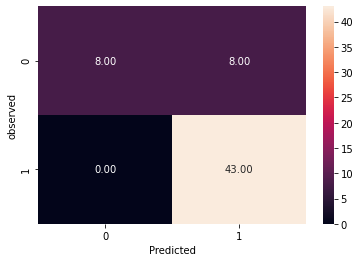

```
Accuracy of  Decision Tree  is 86.4406779661017 %
F1-score of  Decision Tree  is 91.48936170212765 %
Classification report for  Decision Tree  is:
               precision    recall  f1-score   support

           0       1.00      0.50      0.67        16
           1       0.84      1.00      0.91        43

    accuracy                           0.86        59
   macro avg       0.92      0.75      0.79        59
weighted avg       0.89      0.86      0.85        59

AUC for  Decision Tree : 75.0
```

|  | Model | Train Accu | Test Accu | F1-Score | Recall | AUC |
| --- | --- | --- | --- | --- | --- | --- |
| 0 | KNN | 94.85 | 94.92 | 96.47 | 95.35 | 94.55 |
| 1 | SVC | 76.47 | 74.58 | 85.15 | 100.00 | 53.12 |
| 2 | Naive Bayes | 67.65 | 86.44 | 90.24 | 86.05 | 86.77 |
| 3 | Logistic Regression | 84.56 | 86.44 | 91.49 | 100.00 | 75.00 |
| 4 | Meta Classifier | 94.85 | 94.92 | 96.55 | 97.67 | 92.59 |
| 5 | Decision Tree | 86.76 | 86.44 | 91.49 | 100.00 | 75.00 |

```python
#Draw Confusion Matrix and Classification Report for Bagging
Print_CM_CR_AUC(y_test,dTree_predicted_labels, "Decision Tree")
perfDF = BuildPerformanceData(dTree, "Decision Tree", dTree_predicted_labels, perfDF)
perfDF
```

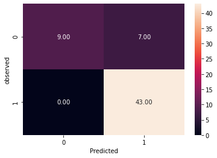

```
Accuracy of  Bagging  is 88.13559322033898 %
F1-score of  Bagging  is 92.4731182795699 %
Classification report for  Bagging  is:
               precision    recall  f1-score   support

           0       1.00      0.56      0.72        16
           1       0.86      1.00      0.92        43

    accuracy                           0.88        59
   macro avg       0.93      0.78      0.82        59
weighted avg       0.90      0.88      0.87        59

AUC for  Bagging : 78.12
```

|  | Model | Train Accu | Test Accu | F1-Score | Recall | AUC |
| --- | --- | --- | --- | --- | --- | --- |
| 0 | KNN | 94.85 | 94.92 | 96.47 | 95.35 | 94.55 |
| 1 | SVC | 76.47 | 74.58 | 85.15 | 100.00 | 53.12 |
| 2 | Naive Bayes | 67.65 | 86.44 | 90.24 | 86.05 | 86.77 |
| 3 | Logistic Regression | 84.56 | 86.44 | 91.49 | 100.00 | 75.00 |
| 4 | Meta Classifier | 94.85 | 94.92 | 96.55 | 97.67 | 92.59 |
| 5 | Decision Tree | 86.76 | 86.44 | 91.49 | 100.00 | 75.00 |
| 6 | Bagging | 87.50 | 88.14 | 92.47 | 100.00 | 78.12 |

```python
#Draw Confusion Matrix and Classification Report for Bagging
Print_CM_CR_AUC(y_test,BGCL_predicted_labels, "Bagging")
perfDF = BuildPerformanceData(BGCL, "Bagging", BGCL_predicted_labels, perfDF)
perfDF
```

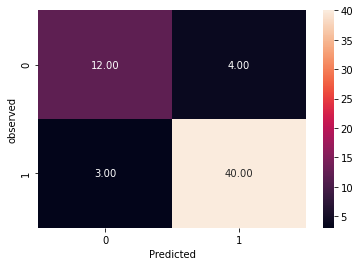

```
Accuracy of  AdaBoost  is 88.13559322033898 %
F1-score of  AdaBoost  is 91.95402298850574 %
Classification report for  AdaBoost  is:
               precision    recall  f1-score   support

           0       0.80      0.75      0.77        16
           1       0.91      0.93      0.92        43

    accuracy                           0.88        59
   macro avg       0.85      0.84      0.85        59
weighted avg       0.88      0.88      0.88        59

AUC for  AdaBoost : 84.01
```

|  | Model | Train Accu | Test Accu | F1-Score | Recall | AUC |
| --- | --- | --- | --- | --- | --- | --- |
| 0 | KNN | 94.85 | 94.92 | 96.47 | 95.35 | 94.55 |
| 1 | SVC | 76.47 | 74.58 | 85.15 | 100.00 | 53.12 |
| 2 | Naive Bayes | 67.65 | 86.44 | 90.24 | 86.05 | 86.77 |
| 3 | Logistic Regression | 84.56 | 86.44 | 91.49 | 100.00 | 75.00 |
| 4 | Meta Classifier | 94.85 | 94.92 | 96.55 | 97.67 | 92.59 |
| 5 | Decision Tree | 86.76 | 86.44 | 91.49 | 100.00 | 75.00 |
| 6 | Bagging | 87.50 | 88.14 | 92.47 | 100.00 | 78.12 |
| 7 | AdaBoost | 96.32 | 88.14 | 91.95 | 93.02 | 84.01 |

```python
#Draw Confusion Matrix and Classification Report for AdaBoost
Print_CM_CR_AUC(y_test,ABCL_predicted_labels, "AdaBoost")
perfDF = BuildPerformanceData(ABCL, "AdaBoost", ABCL_predicted_labels, perfDF)
perfDF
```

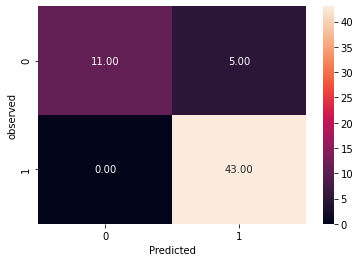

```
Accuracy of  Gradiaent Boost  is 91.52542372881356 %
F1-score of  Gradiaent Boost  is 94.5054945054945 %
Classification report for  Gradiaent Boost  is:
               precision    recall  f1-score   support

           0       1.00      0.69      0.81        16
           1       0.90      1.00      0.95        43

    accuracy                           0.92        59
   macro avg       0.95      0.84      0.88        59
weighted avg       0.92      0.92      0.91        59

AUC for  Gradiaent Boost : 84.38
```

|  | Model | Train Accu | Test Accu | F1-Score | Recall | AUC |
| --- | --- | --- | --- | --- | --- | --- |
| 0 | KNN | 94.85 | 94.92 | 96.47 | 95.35 | 94.55 |
| 1 | SVC | 76.47 | 74.58 | 85.15 | 100.00 | 53.12 |
| 2 | Naive Bayes | 67.65 | 86.44 | 90.24 | 86.05 | 86.77 |
| 3 | Logistic Regression | 84.56 | 86.44 | 91.49 | 100.00 | 75.00 |
| 4 | Meta Classifier | 94.85 | 94.92 | 96.55 | 97.67 | 92.59 |
| 5 | Decision Tree | 86.76 | 86.44 | 91.49 | 100.00 | 75.00 |
| 6 | Bagging | 87.50 | 88.14 | 92.47 | 100.00 | 78.12 |
| 7 | AdaBoost | 96.32 | 88.14 | 91.95 | 93.02 | 84.01 |
| 8 | Gradiaent Boost | 96.32 | 91.53 | 94.51 | 100.00 | 84.38 |

```python
#Draw Confusion Matrix and Classification Report for Gradient Boost
Print_CM_CR_AUC(y_test,GBCL_predicted_labels, "Gradiaent Boost")
perfDF = BuildPerformanceData(GBCL, "Gradiaent Boost", GBCL_predicted_labels, perfDF)
perfDF
```

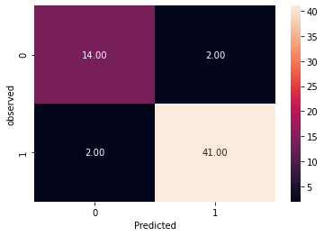

```
Accuracy of  Random Forest  is 93.22033898305084 %
F1-score of  Random Forest  is 95.34883720930233 %
Classification report for  Random Forest  is:
               precision    recall  f1-score   support

           0       0.88      0.88      0.88        16
           1       0.95      0.95      0.95        43

    accuracy                           0.93        59
   macro avg       0.91      0.91      0.91        59
weighted avg       0.93      0.93      0.93        59

AUC for  Random Forest : 91.42
```

|  | Model | Train Accu | Test Accu | F1-Score | Recall | AUC |
| --- | --- | --- | --- | --- | --- | --- |
| 0 | KNN | 94.85 | 94.92 | 96.47 | 95.35 | 94.55 |
| 1 | SVC | 76.47 | 74.58 | 85.15 | 100.00 | 53.12 |
| 2 | Naive Bayes | 67.65 | 86.44 | 90.24 | 86.05 | 86.77 |
| 3 | Logistic Regression | 84.56 | 86.44 | 91.49 | 100.00 | 75.00 |
| 4 | Meta Classifier | 94.85 | 94.92 | 96.55 | 97.67 | 92.59 |
| 5 | Decision Tree | 86.76 | 86.44 | 91.49 | 100.00 | 75.00 |
| 6 | Bagging | 87.50 | 88.14 | 92.47 | 100.00 | 78.12 |
| 7 | AdaBoost | 96.32 | 88.14 | 91.95 | 93.02 | 84.01 |
| 8 | Gradiaent Boost | 96.32 | 91.53 | 94.51 | 100.00 | 84.38 |
| 9 | Random Forest | 98.53 | 93.22 | 95.35 | 95.35 | 91.42 |

```python
#Draw Confusion Matrix and Classification Report for RandomForest
Print_CM_CR_AUC(y_test,RFCL_predicted_labels, "Random Forest")
perfDF = BuildPerformanceData(RFCL, "Random Forest", RFCL_predicted_labels, perfDF)
perfDF
```